# Exploring Weather Trends - Project

Analysis

- CRITERIA
  - MEETS SPECIFICATIONS
1. Student is able to extract data from a database using SQL.
   - The SQL query used to extract the data is included.
   - The query runs without error and pulls the intended data.
1. Student is able to manipulate data in a spreadsheet or similar tool.
   - Moving averages are calculated to be used in the line chart.
1. Student is able to create a clear data visualization.
   - A line chart is included in the submission.
   - The chart and its axes have titles, and there's a clear legend (if applicable).
1. Student is able to interpret a data visualization.
   - The student includes four observations about their provided data visualization.
   - The four observations are accurate.

### Importing libraries

```python
import pandas as pd
import numpy as np
```

## 1. Extraction of data from a database using SQL.

From city_data

```
select * from city_data
```

[figure not shown]

From city_list

```
select * from city_list
```

[figure not shown]

From global_data

```
select * from global_data
```

[figure not shown]

## 2. Manipulation of data in a spreadsheet or similar tool.

Using Jupyter Notebook

```python
# Read city_data
city_data = pd.read_csv('city_data.csv', parse_dates=True)
city_data.head()
```

|  | year | city | country | avg_temp |
| --- | --- | --- | --- | --- |
| 0 | 1849 | Abidjan | Côte D'Ivoire | 25.58 |
| 1 | 1850 | Abidjan | Côte D'Ivoire | 25.52 |
| 2 | 1851 | Abidjan | Côte D'Ivoire | 25.67 |
| 3 | 1856 | Abidjan | Côte D'Ivoire | 26.28 |
| 4 | 1857 | Abidjan | Côte D'Ivoire | 25.17 |

```python
# Read city_list
city_list = pd.read_csv('city_list.csv')
city_list.head()
```

|  | city | country |
| --- | --- | --- |
| 0 | Abidjan | Côte D'Ivoire |
| 1 | Abu Dhabi | United Arab Emirates |
| 2 | Abuja | Nigeria |
| 3 | Accra | Ghana |
| 4 | Adana | Turkey |

```python
# Read global_data
global_data = pd.read_csv('global_data.csv')
global_data.head()
```

|  | year | avg_temp |
| --- | --- | --- |
| 0 | 1750 | 8.72 |
| 1 | 1751 | 7.98 |
| 2 | 1752 | 5.78 |
| 3 | 1753 | 8.39 |
| 4 | 1754 | 8.47 |

```python
# Grouping global data based on year
yearly_grouped = city_data.groupby('year')
yearly_grouped.groups

# Year wise temperature data
global_temp = yearly_grouped.mean()
global_temp.head()
```

| year | avg_temp |
| --- | --- |
| 1743 | 4.725443 |
| 1744 | 11.230253 |
| 1745 | 1.678481 |
| 1750 | 10.424459 |
| 1751 | 10.727838 |

```python
# Data for Patna city
patna_temp = city_data[city_data['city']=='Patna']
patna_temp.head()
```

|  | year | city | country | avg_temp |
| --- | --- | --- | --- | --- |
| 47467 | 1796 | Patna | India | 24.99 |
| 47468 | 1797 | Patna | India | 26.49 |
| 47469 | 1798 | Patna | India | 24.27 |
| 47470 | 1799 | Patna | India | 25.25 |
| 47471 | 1800 | Patna | India | 25.20 |

```python
# Year wise temperature data
patna_temp = patna_temp.iloc[:,[0,3]]
patna_temp.set_index('year', drop=True, inplace=True)
```

```python
patna_temp.head()
```

| year | avg_temp |
| --- | --- |
| 1796 | 24.99 |
| 1797 | 26.49 |
| 1798 | 24.27 |
| 1799 | 25.25 |
| 1800 | 25.20 |

#### Plotting individual graphs for Patna city and global temperatures

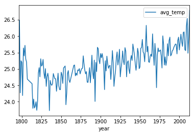

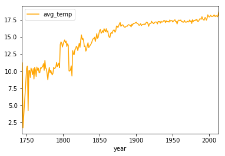

```python
patna_temp.plot(kind='line', label='Patna');
global_temp.plot(kind='line',color='orange');
```

## 3. Clear data visualization.

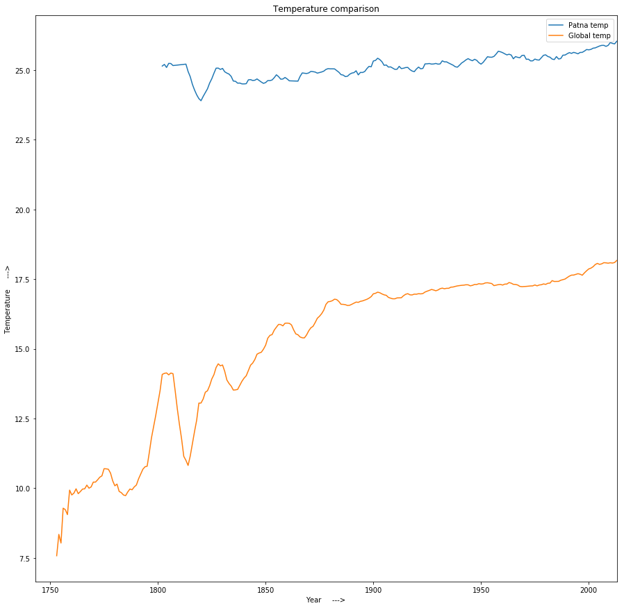

```python
# Plotting both plots on same graph

ax = patna_temp['avg_temp'].rolling(7).mean().plot(figsize=(15,15));
global_temp['avg_temp'].rolling(7).mean().plot(x='Year',legend=True);
# legend(['a','b'])
ax.legend(['Patna temp','Global temp']);
ax.set_xlabel('Year     --->');
ax.set_ylabel('Temperature     --->');
ax.set_title('Temperature comparison');
```

## 4. Interpretation of above data visualization.

- Initial global temperature was very less
- Rate of increase of temperature is more in the global region
- The targeted region has very less significant difference in temperature considered over time
- Global temperature has changed a lot in the last 200 years
- The city taken is hotter than the average global temperature